# Project 2: Comparing DE Genes from a Meditation and Exercise study

### Introduction

#### Scientific Question

> Are the biomarker effects that are shown in meditators associated with the exercise component of the yoga/meditation? In other words, does exercise have similar biomarker effects that meditation has, and could it be one of the factors behind meditation's short and long-term healthy aging effects?

#### Scientific Hypothesis:

> If the biomarker effects seen in meditation are from the exercise component of yoga, then DE genes from an exercise study would be similar to the meditation paper.

#### Genes of interest:

> Differentially expressed genes are genes that show significant differences in expression under two or more different conditions. I sourced all of the gene data from two different papers: 'Meditation and vacation effects have an impact on disease-associated molecular phenotypes and exercise' and 'RNA sequencing on muscle biopsy from a 5-week bed rest study reveals the effect of exercise and potential interactions with dorsal root ganglion neurons'.

#### Description of analyses

> I used Differential Expression Analysis (RNA-Seq), - specifically DESeq2 - volcano plot, and a scatter plot to analyze the data. DE analysis allows for the identification of differentially expressed genes and the volcano plot visualizes that. The scatter plot was an extra method used to compare the two datasets. Data from the meditation paper is sourced from Synapse platform: https://www.synapse.org/#!Synapse:syn7058497. Data from the exercise paper is sourced from NCBI GEO (Gene Expression Omnibus): https://www.ncbi.nlm.nih.gov/geo/query/acc.cgi?acc=GSE186045

### Loading in Packages

#### Definition of each package (10):

> > - pandas: a python library used for working with datasets that has different functions like pd.read_csv() and many more that allow for reading in different files, editing, sorting, and analyzing data. In this project, I used pandas for a lot of different functions, like reading in the file, reindexing, and a lot more to organize the data for DESeq2
> > - numpy: a package in python used for creating arrays, computing mathematical functions, etc. In this project, I used numpy for np.shape() and also in the DESeq2 function.
> > - rpy2: a Python interface to R that allows for Python users to use R functions, by running an emdedded R, so that in this case, we can run DESeq2 function here on this Jupyter notebook.
> > - matplotlib: a library for creating visualizations like scatterplots, bar graphs, and more using specific functions like plt.scatter() and many more to do different things like label, etc. Here, I used it for a scatterplot that compared DE genes of two different RNASeq datasets.
> > - bioinforkit: used for visualization and analysis, as well as interpretation of the data generated from genome-scale omics experiments, like DESeq2 output data. Here, it was used to create a volcano plot where I could visually identify DE genes

```python
import pandas as pd
import numpy as np
#Must install rpy2 first to be able to import these different functions from it
#pip install rpy2
import rpy2.rinterface as rinterface
import rpy2.robjects as robjects
from rpy2.robjects import pandas2ri, numpy2ri, Formula
from rpy2.robjects.conversion import localconverter
from rpy2.robjects.packages import importr
#Need to install matplotlib as well
#pip install matplotlib
import matplotlib.pyplot as plt
import logging
#Have to install bioinfokit
#pip install bioinfokit
from bioinfokit import analys, visuz
```

```
Unable to determine R library path: Command '('C:\\PROGRA~1\\R\\R-41~1.3\\bin\\Rscript', '-e', 'cat(Sys.getenv("LD_LIBRARY_PATH"))')' returned non-zero exit status 1.
```

### Performing Bioinformatics Analysis (20 points)

Meditation Paper by Epel data and things

```python
#Meditation counts
#created a variable using pandas read in f'n for csv files and used sep argument to divide data appropriately
dee = pd.read_csv('DeepakChopra_Tanzi_Meditation.ucsc.Clean.txt', sep="\t")
dee.head()
```

|  | GeneFeature | 1000_baseline_BC_5 | 1001_follow_up | 1003_baseline | 1003_follow_up | 1004_baseline | 1004_follow_up | 1005_baseline | 1005_follow_up | 1006_baseline | ... | 2025_follow_up | 2026_baseline | 2026_follow_up | 2027_baseline | 2027_follow_up | 2028_baseline | 2028_follow_up | 2029_baseline | 2029_follow_up | 2030_baseline |
| --- | --- | --- | --- | --- | --- | --- | --- | --- | --- | --- | --- | --- | --- | --- | --- | --- | --- | --- | --- | --- | --- |
| 0 | 1/2-SBSRNA4 | 18 | 19 | 11 | 19 | 28 | 51 | 59 | 45 | 21 | ... | 20 | 18 | 15 | 7 | 17 | 17 | 28 | 20 | 32 | 15 |
| 1 | A1BG | 424 | 328 | 141 | 205 | 361 | 521 | 611 | 425 | 147 | ... | 186 | 122 | 129 | 91 | 105 | 86 | 146 | 108 | 154 | 97 |
| 2 | A1BG-AS1 | 38 | 33 | 14 | 31 | 35 | 44 | 70 | 68 | 62 | ... | 80 | 56 | 64 | 43 | 39 | 58 | 88 | 86 | 69 | 55 |
| 3 | A1CF | 2 | 2 | 0 | 2 | 2 | 4 | 0 | 0 | 0 | ... | 0 | 1 | 0 | 0 | 0 | 0 | 0 | 0 | 0 | 0 |
| 4 | A2LD1 | 117 | 84 | 80 | 120 | 138 | 128 | 146 | 122 | 116 | ... | 113 | 98 | 90 | 95 | 117 | 102 | 111 | 111 | 132 | 116 |

5 rows × 170 columns

```python
#Creating DESeq2 function (credit to professor/piazza)
#using logging method to get DESeq2
logging.basicConfig(level = logging.INFO)
logger = logging.getLogger('DESeq2')
deseq = importr('DESeq2')
'''
adapted from https://github.com/wckdouglas/diffexpr
example of how it's run is here: https://github.com/wckdouglas/diffexpr/blob/master/example/deseq_example.ipynb
'''

to_dataframe = robjects.r('function(x) data.frame(x)')

#Creating py_DESeq2 function
#defining different f'n within this f'n
#Everything within this f'n is a local variable and everything outside is global
class py_DESeq2:
    '''
    DESeq2 object through rpy2
    Args:
        count_matrix (pd.DataFrame): should be a pandas dataframe with each column as count, and a id column for gene id
        design_matrix (pd.DataFrame): an design matrix in the form of pandas dataframe, see DESeq2 manual, samplenames as rownames
        design_formula (str): see DESeq2 manual, example: "~ treatment""
        gene_column (str): column name of gene id columns, example "id"
    count_matrix example::
        id    sampleA    sampleB
        geneA    5    1
        geneB    4    5
        geneC    1    2
    Design matrix example::
                    treatment
        sampleA1        A
        sampleA2        A
        sampleB1        B
        sampleB2        B
    '''
    #This is setting parameters
    def __init__(self, count_matrix, design_matrix, design_formula, gene_column='id'):
        try:
            assert gene_column in count_matrix.columns, 'Wrong gene id column name'
            gene_id = count_matrix[gene_column]
        except AttributeError:
            sys.exit('Wrong Pandas dataframe?')

        self.dds = None
        self.result = None
        self.deseq_result = None
        self.resLFC = None
        self.comparison = None
        self.normalized_count_df = None
        self.gene_column = gene_column
        self.gene_id = count_matrix[self.gene_column]
        self.samplenames = count_matrix.columns[count_matrix.columns != self.gene_column]
        with localconverter(robjects.default_converter + pandas2ri.converter):
            self.count_matrix = robjects.conversion.py2rpy(count_matrix.set_index(self.gene_column))
            self.design_matrix = robjects.conversion.py2rpy(design_matrix)
        self.design_formula = Formula(design_formula)
        self.dds = deseq.DESeqDataSetFromMatrix(countData=self.count_matrix,
                                        colData=self.design_matrix,
                                        design=self.design_formula)


    # Creating a f'n that runs DESeq2
    #everything within this f'n is a local variable like self
    def run_deseq(self, **kwargs):
        """
        actually running deseq2
        Args:
            **kwargs: Any keyword arguments for DESeq
        From DESeq2 manual:
        DESeq(
            object,
            test = c("Wald", "LRT"),
            fitType = c("parametric", "local", "mean", "glmGamPoi"),
            sfType = c("ratio", "poscounts", "iterate"),
            betaPrior,
            full = design(object),
            reduced,
            quiet = FALSE,
            minReplicatesForReplace = 7,
            modelMatrixType,
            useT = FALSE,
            minmu = if (fitType == "glmGamPoi") 1e-06 else 0.5,
            parallel = FALSE,
            BPPARAM = bpparam()
        )
        """

        for key, value in kwargs.items():
            if key == 'reduced':
                kwargs[key] = Formula(value)
        self.dds = deseq.DESeq(self.dds, **kwargs)
        self.comparison = list(deseq.resultsNames(self.dds))


    #Creating a f'n that gives results/output
    #self, contrast,etc. local variables
    def get_deseq_result(self, contrast=None, **kwargs):
        '''
        DESeq2: result(dds, contrast)
        making a dds.deseq_result pandas dataframe
        '''

        if contrast:
            if len(contrast)==3:
                R_contrast = robjects.vectors.StrVector(np.array(contrast))
            else:
                if len(contrast) != 2:
                    raise ValueError('Contrast must be length of 3 or 2')
                R_contrast = robjects.ListVector({None:con for con in contrast})
            logger.info('Using contrast: %s' %contrast)
            self.result = deseq.results(self.dds, contrast = R_contrast, **kwargs) # Robject
        else:
            self.result = deseq.results(self.dds, **kwargs) # R object
        self.deseq_result = to_dataframe(self.result) # R dataframe
        with localconverter(robjects.default_converter + pandas2ri.converter):
            self.deseq_result = robjects.conversion.rpy2py(self.deseq_result) ## back to pandas dataframe
        self.deseq_result[self.gene_column] = self.gene_id.values

    #creating f'n that normalizes counts and returns as a pandas dataframe
    #local variable here is parameter self
    def normalized_count(self):
        '''
        Returns:
            pd.DataFrame: a dataframe in the format of DESeq2::Counts(dds, normalized=TRUE) in R
        '''
        normalized_count_matrix = deseq.counts_DESeqDataSet(self.dds, normalized=True)
        normalized_count_matrix = to_dataframe(normalized_count_matrix)
        # switch back to python
        with localconverter(robjects.default_converter + pandas2ri.converter):
            self.normalized_count_df = robjects.conversion.rpy2py(normalized_count_matrix)
        self.normalized_count_df[self.gene_column] = self.gene_id.values
        logger.info('Normalizing counts')
        return self.normalized_count_df

    #creating f'n that performs LFC shrinkage
    #Local variables are parameters self, coef, method
    def lfcShrink(self, coef, method = 'apeglm'):
        '''
        Perform LFC shrinkage on the DDS object
        see: http://bioconductor.org/packages/devel/bioc/vignettes/DESeq2/inst/doc/DESeq2.html
        Be sure to check dds.comparison to see which coef (1-base) to use
        Args:
            coef (int): 1-based index for selecting which of dds.comparison to show
            method (str): DESeq2 lfcshrink method ("apeglm", "ashr", "normal")
        Returns:
            pandas.DataFrame: a deseq2 result table
        '''
        lfc = deseq.lfcShrink(self.dds, res = self.result, coef = coef, type = method)
        with localconverter(robjects.default_converter + pandas2ri.converter):
            lfc = robjects.conversion.rpy2py(to_dataframe( lfc))

        return lfc\
            .reset_index()\
            .rename(columns = {'index':self.gene_column})
```

```python
#All of the below is me creating a dataframe from the original exercise dataset with the proper formatting
# for both the count matrix and design matrix so that DESeq2 can actually run

#Loading in raw exercise data using panda's read_excel() f'n
exercise_data = pd.read_excel("Exercise_data.xlsx")
#Only choosing the pre (sedentary) and post (exercise intervention) to see direct gene effects in those individuals
#Raw exercise data has all pre, and post control and post exercise; therefore create new dataframe choosing specific
#columns that are from those specific individuals who had the exercise-intervention
#In addition, ordered so that this count_matrix is in proper format where nrows == ncols with design_matrix
#Creating new dataframe specifying my columns
exercise_data1 = exercise_data[['ensembl Gene ID', 'Gene Name', '1A-PRE', '2B-PRE', '3A-PRE', '4A-PRE', '5B-PRE', '6B1-PRE', '6B2-PRE',
                                '1A-POST', '2B-POST','3A-POST', '4A-POST','5B-POST', '6B1-POST', '6B2-POST']]

#Import SRA run list
#This contains the SRR run assay assigned to each condition
#pandas read in f'n for csv file
run_table = pd.read_csv('SraRunTable (3).txt')
run_table

#Creating dataframe defined as variable srr_data using data from run_table that helps
srr_data = run_table[['Run', 'sample_intervention']]
#reindex f'n to select specific rows
srr_data_final = srr_data.reindex([24, 18, 16, 12, 6 ,2, 0, 25, 19, 17, 13, 7, 3, 1])
srr_data_final

#Creating a dataframe of just gene id
gene_id = exercise_data1['Gene Name']

#Dropping Gene id and Gene Name so that I can convert the floats above into integers to run in DESeq2
#using pandas drop f'n
exercise_counts = exercise_data1.drop(['ensembl Gene ID', 'Gene Name'], axis = 1)
#Renaming columns using their assigned SRR run assay using meta_data
exercise_counts.columns = srr_data_final['Run']
#Making the floats integers
exercise_clean = exercise_counts.astype(int)
#Removing genes with all 0 counts
genes_no_counts = (exercise_clean != 0).any(axis=1)
exercise_clean_counts = exercise_clean.loc[genes_no_counts]
#Creating final exercise datafram that has ensembl gene id, integers, and is ready for DESeq2
exercise_final = pd.merge(gene_id, exercise_clean_counts, left_index=True, right_index=True)
exercise_final
```

|  | Gene Name | SRR16465252 | SRR16465246 | SRR16465244 | SRR16465240 | SRR16465234 | SRR16465230 | SRR16465228 | SRR16465253 | SRR16465247 | SRR16465245 | SRR16465241 | SRR16465235 | SRR16465231 | SRR16465229 |
| --- | --- | --- | --- | --- | --- | --- | --- | --- | --- | --- | --- | --- | --- | --- | --- |
| 2 | A2M | 187 | 220 | 155 | 187 | 152 | 169 | 135 | 298 | 193 | 178 | 265 | 188 | 233 | 215 |
| 5 | A4GALT | 6 | 10 | 8 | 6 | 7 | 12 | 10 | 9 | 8 | 7 | 8 | 4 | 10 | 10 |
| 7 | AAAS | 30 | 31 | 26 | 33 | 35 | 34 | 30 | 37 | 31 | 27 | 32 | 31 | 35 | 34 |
| 8 | AACS | 12 | 16 | 5 | 7 | 10 | 6 | 6 | 10 | 14 | 7 | 8 | 8 | 8 | 7 |
| 12 | AADAT | 1 | 0 | 1 | 2 | 1 | 1 | 1 | 3 | 1 | 3 | 1 | 1 | 2 | 2 |
| ... | ... | ... | ... | ... | ... | ... | ... | ... | ... | ... | ... | ... | ... | ... | ... |
| 17724 | ZXDB | 3 | 2 | 3 | 3 | 3 | 3 | 3 | 2 | 3 | 3 | 2 | 3 | 4 | 3 |
| 17725 | ZXDC | 32 | 31 | 38 | 24 | 27 | 26 | 28 | 26 | 25 | 24 | 28 | 27 | 31 | 29 |
| 17727 | ZYG11B | 111 | 91 | 108 | 135 | 122 | 110 | 127 | 123 | 115 | 157 | 134 | 143 | 147 | 162 |
| 17728 | ZYX | 54 | 75 | 36 | 35 | 41 | 43 | 43 | 46 | 47 | 37 | 49 | 36 | 36 | 41 |
| 17729 | ZZEF1 | 62 | 64 | 77 | 66 | 49 | 47 | 49 | 69 | 65 | 76 | 65 | 59 | 50 | 48 |

12531 rows × 15 columns

```python
#Read in csv file using pandas read_excel() and making 'id' index
metadata = pd.read_excel('only_exercise_meta.xlsx', index_col=0)
metadata
```

| id | condition |
| --- | --- |
| SRR16465252 | pre |
| SRR16465246 | pre |
| SRR16465244 | pre |
| SRR16465240 | pre |
| SRR16465234 | pre |
| SRR16465230 | pre |
| SRR16465228 | pre |
| SRR16465253 | Exercise |
| SRR16465247 | Exercise |
| SRR16465245 | Exercise |
| SRR16465241 | Exercise |
| SRR16465235 | Exercise |
| SRR16465231 | Exercise |
| SRR16465229 | Exercise |

```python
#creating variable dds that is running DESeq2 f'n created
#4 parameters and setting them equal to the files that I've loaded in and organized
dds = py_DESeq2(count_matrix=exercise_final,
               design_matrix=metadata,
               design_formula="~condition",
               gene_column="Gene Name")
dds.run_deseq() #run_deseq() to run DESeq2 on dds
dds.get_deseq_result() #get_... f'n to get result
exercise_final = dds.deseq_result #setting result equal to variable
exercise_final.head() #.head() to display first few rows of output
```

[output not shown]

|  | baseMean | log2FoldChange | lfcSE | stat | pvalue | padj | Gene Name |
| --- | --- | --- | --- | --- | --- | --- | --- |
| A2M | 195.996827 | -0.318234 | 0.121137 | -2.627052 | 0.008613 | 0.933723 | A2M |
| A4GALT | 8.164688 | 0.137173 | 0.326194 | 0.420525 | 0.674102 | 0.999800 | A4GALT |
| AAAS | 31.664293 | 0.008718 | 0.162577 | 0.053625 | 0.957234 | 0.999800 | AAAS |
| AACS | 8.824408 | 0.055518 | 0.342391 | 0.162147 | 0.871190 | 0.999800 | AACS |
| AADAT | 1.402467 | -0.827270 | 0.788377 | -1.049334 | 0.294025 | NaN | AADAT |

```python
#Meditation DESeq2 output loaded in using pandas read_csv()
meditation_output = pd.read_csv('Proj2_meditation_output.csv')
meditation_output
```

|  | baseMean | log2FoldChange | lfcSE | stat | pvalue | padj | Gene Name |
| --- | --- | --- | --- | --- | --- | --- | --- |
| 0 | 13.855150 | 0.050621 | 0.102791 | 0.492466 | 0.622390 | 0.99973 | 1/2-SBSRNA4 |
| 1 | 112.379617 | -0.026336 | 0.108009 | -0.243833 | 0.807360 | 0.99973 | A1BG |
| 2 | 48.866632 | 0.053429 | 0.061438 | 0.869651 | 0.384491 | 0.99973 | A1BG-AS1 |
| 3 | 0.625973 | 0.240869 | 0.392218 | 0.614121 | 0.539136 | 0.99973 | A1CF |
| 4 | 84.080699 | -0.024912 | 0.065980 | -0.377572 | 0.705748 | 0.99973 | A2LD1 |
| ... | ... | ... | ... | ... | ... | ... | ... |
| 23223 | 14998.800800 | -0.066345 | 0.089661 | -0.739949 | 0.459331 | 0.99973 | ZYX |
| 23224 | 2668.783194 | -0.009647 | 0.062229 | -0.155026 | 0.876801 | 0.99973 | ZZEF1 |
| 23225 | 309.998585 | 0.089258 | 0.066398 | 1.344290 | 0.178855 | 0.99973 | ZZZ3 |
| 23226 | 113.529607 | -0.153761 | 0.114353 | -1.344617 | 0.178749 | 0.99973 | psiTPTE22 |
| 23227 | 0.236243 | -0.617055 | 0.693707 | -0.889504 | 0.373732 | 0.99973 | tAKR |

23228 rows × 7 columns

```python
#Looking at two different data sets amount of genes
print(exercise_final.shape)
print(meditation_output.shape)
```

```
(12531, 7)
(23228, 7)
```

```python
#Creating variable of sorted dataframe using .sort_values and setting by parameter to my specific column
med_adjusted = meditation_output.sort_values(by='log2FoldChange', ascending = False)
#Drop any rows with NaN value
med_adjusted.dropna()
#Creating new variable that has first 12,531 genes to compare with exercise dataset in scatter plot
med_compare = med_adjusted.iloc[:12531,:]
med_compare
```

|  | baseMean | log2FoldChange | lfcSE | stat | pvalue | padj | Gene Name |
| --- | --- | --- | --- | --- | --- | --- | --- |
| 5446 | 0.447916 | 1.449727 | 1.027585 | 1.410810 | 0.158301 | 0.99973 | EFEMP1 |
| 2848 | 0.429323 | 1.282499 | 0.593080 | 2.162439 | 0.030584 | 0.99973 | CAMK2A |
| 4005 | 0.504711 | 1.274284 | 0.663043 | 1.921871 | 0.054622 | 0.99973 | COL14A1 |
| 13667 | 0.303179 | 1.216136 | 1.287579 | 0.944514 | 0.344907 | 0.99973 | MXRA5 |
| 7599 | 0.363187 | 1.204494 | 0.894981 | 1.345832 | 0.178357 | 0.99973 | GRIA1 |
| ... | ... | ... | ... | ... | ... | ... | ... |
| 20558 | 180.050265 | -0.035117 | 0.076343 | -0.459991 | 0.645523 | 0.99973 | THAP1 |
| 20221 | 792.497117 | -0.035123 | 0.062316 | -0.563627 | 0.573008 | 0.99973 | TAF6 |
| 10502 | 85.071365 | -0.035124 | 0.145237 | -0.241842 | 0.808903 | 0.99973 | LOC148696 |
| 6779 | 2318.687673 | -0.035142 | 0.063150 | -0.556478 | 0.577884 | 0.99973 | FOXN3 |
| 9384 | 848.117204 | -0.035150 | 0.101022 | -0.347947 | 0.727880 | 0.99973 | KLHL2 |

12531 rows × 7 columns

### Plotting The Results (15 points)

- 5 points for description of data analysis method
- 5 points for the code working for data analysis method
- 5 points for adequate commenting in the code for the data analysis method

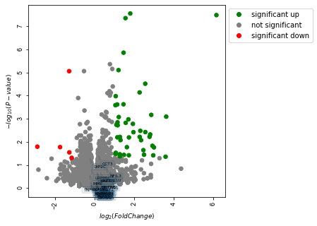

```python
#Using bioinfokit's Visuz.geneexpression to create volcano plot
#setting parameters to respective dataframe (exercise output) and columns for other parameters
#Set gene names equal to those specific genes that I found from, according to original meditation study, to be significant
#meditation genes associated with healthy aging
visuz.GeneExpression.volcano(df=exercise_final, lfc='log2FoldChange', pv='pvalue', geneid="Gene Name", plotlegend=True, legendpos='upper right',
    legendanchor=(1.46,1), genenames=("MME","ODC1","OAZ1","OAZ2","FOXO3", "NFIL3", "CLU", "PSEN1", "NOP2", "PPRC1", " DKC1",
                                      "PDCD11", "TNFRSF10D", "FEN1", "ZNF416", "PLD6", "LDHB", "BZW2", "SRPRB",
                                      "GRAP", "DIP2C", "NAF1", "RTEL1", "PDCD11", "STRAP", "PPRC1",
                                      "TNFRSF10D", "NHP2", "TERF2", "CTC1", "CCT3", "UTP14A", "ADSL", "IMPDH2",
                                      "ATMIN", "LOC100133445", "ZNF419", "SMYD5", "XRCC6", "RNASEH2A", "XRCC1",
                                      "AFG3L2", "ZNF557", "STMN1", "WDR65", "PHF10", "LRPPRC", "MORC2-AS1"), gstyle=2, dotsize=30, show=True)
```

Zoomed in

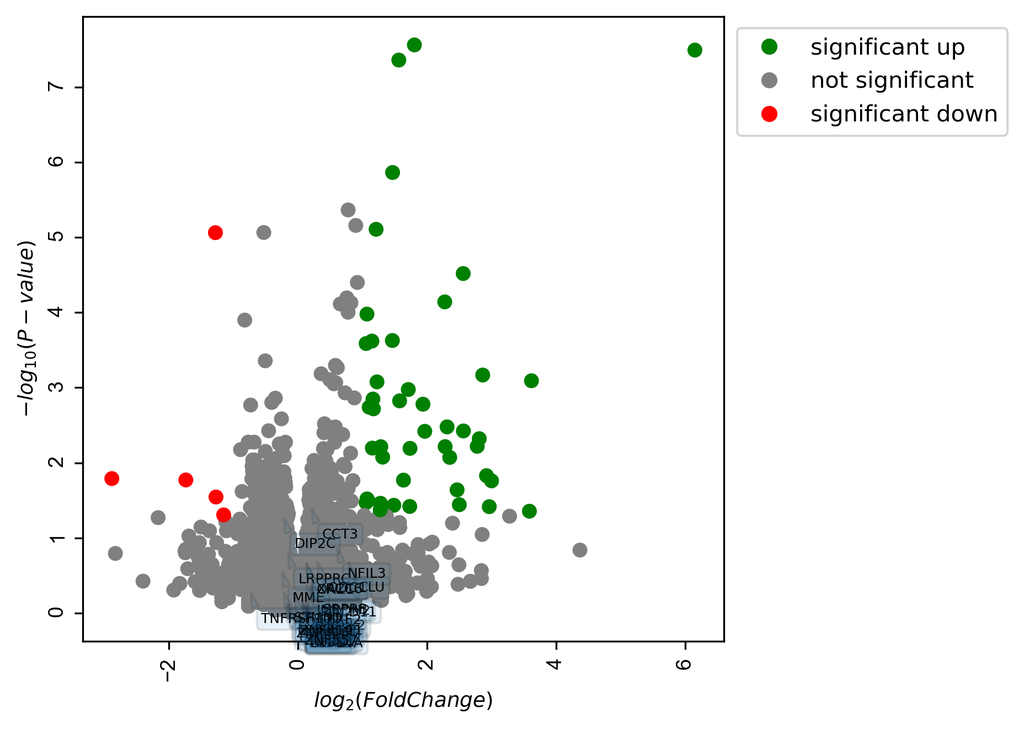

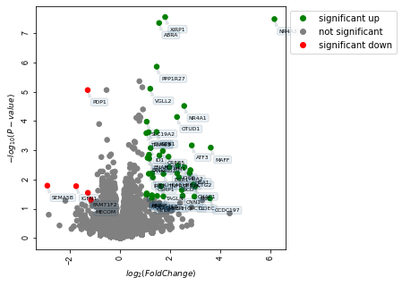

```python
#Same thing as above except labelling the DE genes exercise data has
visuz.GeneExpression.volcano(df=exercise_final, lfc='log2FoldChange', pv='pvalue', geneid="Gene Name", plotlegend=True, legendpos='upper right',
    legendanchor=(1.46,1), genenames= 'deg', gstyle=2, dotsize=30, show=True)
```

Zoomed in

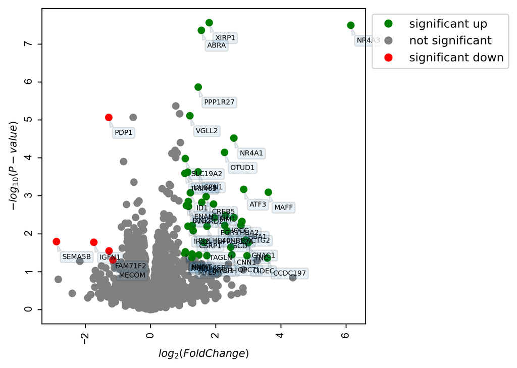

```python
#Now going to use logfoldchange column to create scatterplot comparing genes of meditation and exercise study
meditation_de_genes = med_compare['log2FoldChange']
exercise_study = exercise_final['log2FoldChange']
```

[figure not shown]

```python
#Using matplotlib figure function, labelling, etc. to set figure dimensions and more
plt.figure()
plt.figure(figsize=(10,10))
plt.xticks(fontsize=12)
plt.yticks(fontsize=14)
plt.xlabel('Exercise DE genes', fontsize=20)
plt.ylabel('Meditation DE genes',fontsize=20)
plt.title("DE Gene correlation",fontsize=15)

#Attempted to label dots according to color of p-values
sig_status = ['Significant: p-value<0.05', 'Not Significant: p-value>0.05']
#Create variable scatter to plot scatter plot comparing exercise's log2FoldChange and meditation's log2FoldChange
# c is parameter for color and used .astype('category').cat.codes to label according to exercise_final's pvalues
scatter = plt.scatter(exercise_study
               , meditation_de_genes, c = exercise_final.pvalue.astype('category').cat.codes, s = 100)
#.legend() to plot legend with respective parameters identified on top
plt.legend(handles=scatter.legend_elements()[0],
           labels=sig_status,
           title="Significance")
```

### Analyzing the Results (15 points)

- When plotting the volcano plot, the first volcano plot shows exercise study's DE genes, but with the paper's written significant DE genes labelled. As you could see, they were all in the insignificant zone for the exercise volcano plot. Going off of that, it's safe to lightly assume that exercise and meditation may not have the same direct biomarker effects. However, it's possible that the dataset I compared it to was not a good one to compare to since it was difficult to separate the data from 'dee' into different conditions, which there were, aside from baseline and followup.
- I also created a scatterplot and it showed the genes in general from both. However, to plot it, I had to omit data from the meditation paper that I tried to go around by sorting by LFC before choosing rows to match exercise data. The color coding made it difficult to understand which genes are from which, but overall the shape of the scatterplot implies that there isn't really a noticeable correlation/strong correlation associated with the two different conditions: exercide and meditation biomarker effects.